# Part I - Prosper Loan Data

## Introduction

> This data set contains 113,937 loans with 81 features, including loan amount, borrower rate (or interest rate), current loan status, borrower income, and many others.

## Preliminary Wrangling

```python
# import all packages and set plots to be embedded inline

import pandas as pd
import numpy as np
import seaborn as sb
import matplotlib.pyplot as plt

%matplotlib inline
# load in the dataset into a pandas dataframe, print statistics
df = pd.read_csv('prosperLoanData.csv')
df.head()
```

|  | ListingKey | ListingNumber | ListingCreationDate | CreditGrade | Term | LoanStatus | ClosedDate | BorrowerAPR | BorrowerRate | LenderYield | ... | LP_ServiceFees | LP_CollectionFees | LP_GrossPrincipalLoss | LP_NetPrincipalLoss | LP_NonPrincipalRecoverypayments | PercentFunded | Recommendations | InvestmentFromFriendsCount | InvestmentFromFriendsAmount | Investors |
| --- | --- | --- | --- | --- | --- | --- | --- | --- | --- | --- | --- | --- | --- | --- | --- | --- | --- | --- | --- | --- | --- |
| 0 | 1021339766868145413AB3B | 193129 | 2007-08-26 19:09:29.263000000 | C | 36 | Completed | 2009-08-14 00:00:00 | 0.16516 | 0.1580 | 0.1380 | ... | -133.18 | 0.0 | 0.0 | 0.0 | 0.0 | 1.0 | 0 | 0 | 0.0 | 258 |
| 1 | 10273602499503308B223C1 | 1209647 | 2014-02-27 08:28:07.900000000 | NaN | 36 | Current | NaN | 0.12016 | 0.0920 | 0.0820 | ... | 0.00 | 0.0 | 0.0 | 0.0 | 0.0 | 1.0 | 0 | 0 | 0.0 | 1 |
| 2 | 0EE9337825851032864889A | 81716 | 2007-01-05 15:00:47.090000000 | HR | 36 | Completed | 2009-12-17 00:00:00 | 0.28269 | 0.2750 | 0.2400 | ... | -24.20 | 0.0 | 0.0 | 0.0 | 0.0 | 1.0 | 0 | 0 | 0.0 | 41 |
| 3 | 0EF5356002482715299901A | 658116 | 2012-10-22 11:02:35.010000000 | NaN | 36 | Current | NaN | 0.12528 | 0.0974 | 0.0874 | ... | -108.01 | 0.0 | 0.0 | 0.0 | 0.0 | 1.0 | 0 | 0 | 0.0 | 158 |
| 4 | 0F023589499656230C5E3E2 | 909464 | 2013-09-14 18:38:39.097000000 | NaN | 36 | Current | NaN | 0.24614 | 0.2085 | 0.1985 | ... | -60.27 | 0.0 | 0.0 | 0.0 | 0.0 | 1.0 | 0 | 0 | 0.0 | 20 |

5 rows × 81 columns

```python
# high-level overview of data shape and composition
print(df.shape)
print(df.dtypes)
```

```
(113937, 81)
ListingKey                      object
ListingNumber                    int64
ListingCreationDate             object
CreditGrade                     object
Term                             int64
                                ...
PercentFunded                  float64
Recommendations                  int64
InvestmentFromFriendsCount       int64
InvestmentFromFriendsAmount    float64
Investors                        int64
Length: 81, dtype: object
```

```python
#to see all the columns names
list(df)
```

```
['ListingKey',
 'ListingNumber',
 'ListingCreationDate',
 'CreditGrade',
 'Term',
 'LoanStatus',
 'ClosedDate',
 'BorrowerAPR',
 'BorrowerRate',
 'LenderYield',
 'EstimatedEffectiveYield',
 'EstimatedLoss',
 'EstimatedReturn',
 'ProsperRating (numeric)',
 'ProsperRating (Alpha)',
 'ProsperScore',
 'ListingCategory (numeric)',
 'BorrowerState',
 'Occupation',
 'EmploymentStatus',
 'EmploymentStatusDuration',
 'IsBorrowerHomeowner',
 'CurrentlyInGroup',
 'GroupKey',
 'DateCreditPulled',
 'CreditScoreRangeLower',
 'CreditScoreRangeUpper',
 'FirstRecordedCreditLine',
 'CurrentCreditLines',
 'OpenCreditLines',
 'TotalCreditLinespast7years',
 'OpenRevolvingAccounts',
 'OpenRevolvingMonthlyPayment',
 'InquiriesLast6Months',
 'TotalInquiries',
 'CurrentDelinquencies',
 'AmountDelinquent',
 'DelinquenciesLast7Years',
 'PublicRecordsLast10Years',
 'PublicRecordsLast12Months',
```

[output cut: 26 more lines]

```
 'MemberKey',
 'MonthlyLoanPayment',
 'LP_CustomerPayments',
 'LP_CustomerPrincipalPayments',
 'LP_InterestandFees',
 'LP_ServiceFees',
 'LP_CollectionFees',
 'LP_GrossPrincipalLoss',
 'LP_NetPrincipalLoss',
 'LP_NonPrincipalRecoverypayments',
 'PercentFunded',
 'Recommendations',
 'InvestmentFromFriendsCount',
 'InvestmentFromFriendsAmount',
 'Investors']
```

```python
# descriptive statistics for numeric variables
print(df.describe())
```

```
       ListingNumber           Term    BorrowerAPR   BorrowerRate  \
count   1.139370e+05  113937.000000  113912.000000  113937.000000
mean    6.278857e+05      40.830248       0.218828       0.192764
std     3.280762e+05      10.436212       0.080364       0.074818
min     4.000000e+00      12.000000       0.006530       0.000000
25%     4.009190e+05      36.000000       0.156290       0.134000
50%     6.005540e+05      36.000000       0.209760       0.184000
75%     8.926340e+05      36.000000       0.283810       0.250000
max     1.255725e+06      60.000000       0.512290       0.497500

         LenderYield  EstimatedEffectiveYield  EstimatedLoss  EstimatedReturn  \
count  113937.000000             84853.000000   84853.000000     84853.000000
mean        0.182701                 0.168661       0.080306         0.096068
std         0.074516                 0.068467       0.046764         0.030403
min        -0.010000                -0.182700       0.004900        -0.182700
25%         0.124200                 0.115670       0.042400         0.074080
50%         0.173000                 0.161500       0.072400         0.091700
75%         0.240000                 0.224300       0.112000         0.116600
max         0.492500                 0.319900       0.366000         0.283700

       ProsperRating (numeric)  ProsperScore  ...  LP_ServiceFees  \
count             84853.000000  84853.000000  ...   113937.000000
mean                  4.072243      5.950067  ...      -54.725641
std                   1.673227      2.376501  ...       60.675425
min                   1.000000      1.000000  ...     -664.870000
25%                   3.000000      4.000000  ...      -73.180000
50%                   4.000000      6.000000  ...      -34.440000
75%                   5.000000      8.000000  ...      -13.920000
max                   7.000000     11.000000  ...       32.060000

       LP_CollectionFees  LP_GrossPrincipalLoss  LP_NetPrincipalLoss  \
count      113937.000000          113937.000000        113937.000000
mean          -14.242698             700.446342           681.420499
std           109.232758            2388.513831          2357.167068
min         -9274.750000             -94.200000          -954.550000
25%             0.000000               0.000000             0.000000
50%             0.000000               0.000000             0.000000
75%             0.000000               0.000000             0.000000
max             0.000000           25000.000000         25000.000000

       LP_NonPrincipalRecoverypayments  PercentFunded  Recommendations  \
count                    113937.000000  113937.000000    113937.000000
mean                         25.142686       0.998584         0.048027
std                         275.657937       0.017919         0.332353
min                           0.000000       0.700000         0.000000
25%                           0.000000       1.000000         0.000000
50%                           0.000000       1.000000         0.000000
75%                           0.000000       1.000000         0.000000
max                       21117.900000       1.012500        39.000000

       InvestmentFromFriendsCount  InvestmentFromFriendsAmount      Investors
count               113937.000000                113937.000000  113937.000000
mean                     0.023460                    16.550751      80.475228
std                      0.232412                   294.545422     103.239020
min                      0.000000                     0.000000       1.000000
25%                      0.000000                     0.000000       2.000000
50%                      0.000000                     0.000000      44.000000
75%                      0.000000                     0.000000     115.000000
max                     33.000000                 25000.000000    1189.000000

[8 rows x 61 columns]
```

```python
#i wanted to observe every column
df.iloc[ :10 ,10:20]
```

|  | EstimatedEffectiveYield | EstimatedLoss | EstimatedReturn | ProsperRating (numeric) | ProsperRating (Alpha) | ProsperScore | ListingCategory (numeric) | BorrowerState | Occupation | EmploymentStatus |
| --- | --- | --- | --- | --- | --- | --- | --- | --- | --- | --- |
| 0 | NaN | NaN | NaN | NaN | NaN | NaN | 0 | CO | Other | Self-employed |
| 1 | 0.07960 | 0.0249 | 0.05470 | 6.0 | A | 7.0 | 2 | CO | Professional | Employed |
| 2 | NaN | NaN | NaN | NaN | NaN | NaN | 0 | GA | Other | Not available |
| 3 | 0.08490 | 0.0249 | 0.06000 | 6.0 | A | 9.0 | 16 | GA | Skilled Labor | Employed |
| 4 | 0.18316 | 0.0925 | 0.09066 | 3.0 | D | 4.0 | 2 | MN | Executive | Employed |
| 5 | 0.11567 | 0.0449 | 0.07077 | 5.0 | B | 10.0 | 1 | NM | Professional | Employed |
| 6 | 0.23820 | 0.1275 | 0.11070 | 2.0 | E | 2.0 | 1 | KS | Sales - Retail | Employed |
| 7 | 0.17830 | 0.0799 | 0.09840 | 4.0 | C | 4.0 | 2 | CA | Laborer | Employed |
| 8 | 0.05221 | 0.0099 | 0.04231 | 7.0 | AA | 9.0 | 7 | IL | Food Service | Employed |
| 9 | 0.05221 | 0.0099 | 0.04231 | 7.0 | AA | 11.0 | 7 | IL | Food Service | Employed |

```python
df.iloc[ :10 ,20:30]
```

|  | EmploymentStatusDuration | IsBorrowerHomeowner | CurrentlyInGroup | GroupKey | DateCreditPulled | CreditScoreRangeLower | CreditScoreRangeUpper | FirstRecordedCreditLine | CurrentCreditLines | OpenCreditLines |
| --- | --- | --- | --- | --- | --- | --- | --- | --- | --- | --- |
| 0 | 2.0 | True | True | NaN | 2007-08-26 18:41:46.780000000 | 640.0 | 659.0 | 2001-10-11 00:00:00 | 5.0 | 4.0 |
| 1 | 44.0 | False | False | NaN | 2014-02-27 08:28:14 | 680.0 | 699.0 | 1996-03-18 00:00:00 | 14.0 | 14.0 |
| 2 | NaN | False | True | 783C3371218786870A73D20 | 2007-01-02 14:09:10.060000000 | 480.0 | 499.0 | 2002-07-27 00:00:00 | NaN | NaN |
| 3 | 113.0 | True | False | NaN | 2012-10-22 11:02:32 | 800.0 | 819.0 | 1983-02-28 00:00:00 | 5.0 | 5.0 |
| 4 | 44.0 | True | False | NaN | 2013-09-14 18:38:44 | 680.0 | 699.0 | 2004-02-20 00:00:00 | 19.0 | 19.0 |
| 5 | 82.0 | True | False | NaN | 2013-12-14 08:26:40 | 740.0 | 759.0 | 1973-03-01 00:00:00 | 21.0 | 17.0 |
| 6 | 172.0 | False | False | NaN | 2013-04-12 09:52:53 | 680.0 | 699.0 | 2000-09-29 00:00:00 | 10.0 | 7.0 |
| 7 | 103.0 | False | False | NaN | 2013-05-05 06:49:25 | 700.0 | 719.0 | 1999-02-25 00:00:00 | 6.0 | 6.0 |
| 8 | 269.0 | True | False | NaN | 2013-12-02 10:43:39 | 820.0 | 839.0 | 1993-04-01 00:00:00 | 17.0 | 16.0 |
| 9 | 269.0 | True | False | NaN | 2013-12-02 10:43:39 | 820.0 | 839.0 | 1993-04-01 00:00:00 | 17.0 | 16.0 |

```python
df.iloc[ :10 ,30:40]
```

|  | TotalCreditLinespast7years | OpenRevolvingAccounts | OpenRevolvingMonthlyPayment | InquiriesLast6Months | TotalInquiries | CurrentDelinquencies | AmountDelinquent | DelinquenciesLast7Years | PublicRecordsLast10Years | PublicRecordsLast12Months |
| --- | --- | --- | --- | --- | --- | --- | --- | --- | --- | --- |
| 0 | 12.0 | 1 | 24.0 | 3.0 | 3.0 | 2.0 | 472.0 | 4.0 | 0.0 | 0.0 |
| 1 | 29.0 | 13 | 389.0 | 3.0 | 5.0 | 0.0 | 0.0 | 0.0 | 1.0 | 0.0 |
| 2 | 3.0 | 0 | 0.0 | 0.0 | 1.0 | 1.0 | NaN | 0.0 | 0.0 | NaN |
| 3 | 29.0 | 7 | 115.0 | 0.0 | 1.0 | 4.0 | 10056.0 | 14.0 | 0.0 | 0.0 |
| 4 | 49.0 | 6 | 220.0 | 1.0 | 9.0 | 0.0 | 0.0 | 0.0 | 0.0 | 0.0 |
| 5 | 49.0 | 13 | 1410.0 | 0.0 | 2.0 | 0.0 | 0.0 | 0.0 | 0.0 | 0.0 |
| 6 | 20.0 | 6 | 214.0 | 0.0 | 0.0 | 0.0 | 0.0 | 0.0 | 0.0 | 0.0 |
| 7 | 10.0 | 5 | 101.0 | 3.0 | 16.0 | 0.0 | 0.0 | 0.0 | 1.0 | 0.0 |
| 8 | 32.0 | 12 | 219.0 | 1.0 | 6.0 | 0.0 | 0.0 | 0.0 | 0.0 | 0.0 |
| 9 | 32.0 | 12 | 219.0 | 1.0 | 6.0 | 0.0 | 0.0 | 0.0 | 0.0 | 0.0 |

```python
df.iloc[ :10 ,40:50]
```

|  | RevolvingCreditBalance | BankcardUtilization | AvailableBankcardCredit | TotalTrades | TradesNeverDelinquent (percentage) | TradesOpenedLast6Months | DebtToIncomeRatio | IncomeRange | IncomeVerifiable | StatedMonthlyIncome |
| --- | --- | --- | --- | --- | --- | --- | --- | --- | --- | --- |
| 0 | 0.0 | 0.00 | 1500.0 | 11.0 | 0.81 | 0.0 | 0.17 | $25,000-49,999 | True | 3083.333333 |
| 1 | 3989.0 | 0.21 | 10266.0 | 29.0 | 1.00 | 2.0 | 0.18 | $50,000-74,999 | True | 6125.000000 |
| 2 | NaN | NaN | NaN | NaN | NaN | NaN | 0.06 | Not displayed | True | 2083.333333 |
| 3 | 1444.0 | 0.04 | 30754.0 | 26.0 | 0.76 | 0.0 | 0.15 | $25,000-49,999 | True | 2875.000000 |
| 4 | 6193.0 | 0.81 | 695.0 | 39.0 | 0.95 | 2.0 | 0.26 | $100,000+ | True | 9583.333333 |
| 5 | 62999.0 | 0.39 | 86509.0 | 47.0 | 1.00 | 0.0 | 0.36 | $100,000+ | True | 8333.333333 |
| 6 | 5812.0 | 0.72 | 1929.0 | 16.0 | 0.68 | 0.0 | 0.27 | $25,000-49,999 | True | 2083.333333 |
| 7 | 1260.0 | 0.13 | 2181.0 | 10.0 | 0.80 | 0.0 | 0.24 | $25,000-49,999 | True | 3355.750000 |
| 8 | 9906.0 | 0.11 | 77696.0 | 29.0 | 1.00 | 1.0 | 0.25 | $25,000-49,999 | True | 3333.333333 |
| 9 | 9906.0 | 0.11 | 77696.0 | 29.0 | 1.00 | 1.0 | 0.25 | $25,000-49,999 | True | 3333.333333 |

```python
df.iloc[ :10 ,50:60]
```

|  | LoanKey | TotalProsperLoans | TotalProsperPaymentsBilled | OnTimeProsperPayments | ProsperPaymentsLessThanOneMonthLate | ProsperPaymentsOneMonthPlusLate | ProsperPrincipalBorrowed | ProsperPrincipalOutstanding | ScorexChangeAtTimeOfListing | LoanCurrentDaysDelinquent |
| --- | --- | --- | --- | --- | --- | --- | --- | --- | --- | --- |
| 0 | E33A3400205839220442E84 | NaN | NaN | NaN | NaN | NaN | NaN | NaN | NaN | 0 |
| 1 | 9E3B37071505919926B1D82 | NaN | NaN | NaN | NaN | NaN | NaN | NaN | NaN | 0 |
| 2 | 6954337960046817851BCB2 | NaN | NaN | NaN | NaN | NaN | NaN | NaN | NaN | 0 |
| 3 | A0393664465886295619C51 | NaN | NaN | NaN | NaN | NaN | NaN | NaN | NaN | 0 |
| 4 | A180369302188889200689E | 1.0 | 11.0 | 11.0 | 0.0 | 0.0 | 11000.0 | 9947.9 | NaN | 0 |
| 5 | C3D63702273952547E79520 | NaN | NaN | NaN | NaN | NaN | NaN | NaN | NaN | 0 |
| 6 | CE963680102927767790520 | NaN | NaN | NaN | NaN | NaN | NaN | NaN | NaN | 0 |
| 7 | 0C87368108902149313D53B | NaN | NaN | NaN | NaN | NaN | NaN | NaN | NaN | 0 |
| 8 | 02163700809231365A56A1C | NaN | NaN | NaN | NaN | NaN | NaN | NaN | NaN | 0 |
| 9 | 02163700809231365A56A1C | NaN | NaN | NaN | NaN | NaN | NaN | NaN | NaN | 0 |

```python
df.iloc[ :10 ,60:70]
```

|  | LoanFirstDefaultedCycleNumber | LoanMonthsSinceOrigination | LoanNumber | LoanOriginalAmount | LoanOriginationDate | LoanOriginationQuarter | MemberKey | MonthlyLoanPayment | LP_CustomerPayments | LP_CustomerPrincipalPayments |
| --- | --- | --- | --- | --- | --- | --- | --- | --- | --- | --- |
| 0 | NaN | 78 | 19141 | 9425 | 2007-09-12 00:00:00 | Q3 2007 | 1F3E3376408759268057EDA | 330.43 | 11396.14 | 9425.00 |
| 1 | NaN | 0 | 134815 | 10000 | 2014-03-03 00:00:00 | Q1 2014 | 1D13370546739025387B2F4 | 318.93 | 0.00 | 0.00 |
| 2 | NaN | 86 | 6466 | 3001 | 2007-01-17 00:00:00 | Q1 2007 | 5F7033715035555618FA612 | 123.32 | 4186.63 | 3001.00 |
| 3 | NaN | 16 | 77296 | 10000 | 2012-11-01 00:00:00 | Q4 2012 | 9ADE356069835475068C6D2 | 321.45 | 5143.20 | 4091.09 |
| 4 | NaN | 6 | 102670 | 15000 | 2013-09-20 00:00:00 | Q3 2013 | 36CE356043264555721F06C | 563.97 | 2819.85 | 1563.22 |
| 5 | NaN | 3 | 123257 | 15000 | 2013-12-24 00:00:00 | Q4 2013 | 874A3701157341738DE458F | 342.37 | 679.34 | 351.89 |
| 6 | NaN | 11 | 88353 | 3000 | 2013-04-18 00:00:00 | Q2 2013 | AA4535764146102879D5959 | 122.67 | 1226.70 | 604.25 |
| 7 | NaN | 10 | 90051 | 10000 | 2013-05-13 00:00:00 | Q2 2013 | 737F347089545035681C074 | 372.60 | 3353.40 | 1955.89 |
| 8 | NaN | 3 | 121268 | 10000 | 2013-12-12 00:00:00 | Q4 2013 | 49A53699682291323D04D66 | 305.54 | 611.08 | 505.58 |
| 9 | NaN | 3 | 121268 | 10000 | 2013-12-12 00:00:00 | Q4 2013 | 49A53699682291323D04D66 | 305.54 | 611.08 | 505.58 |

```python
df.iloc[ :10 ,70:]
```

|  | LP_InterestandFees | LP_ServiceFees | LP_CollectionFees | LP_GrossPrincipalLoss | LP_NetPrincipalLoss | LP_NonPrincipalRecoverypayments | PercentFunded | Recommendations | InvestmentFromFriendsCount | InvestmentFromFriendsAmount | Investors |
| --- | --- | --- | --- | --- | --- | --- | --- | --- | --- | --- | --- |
| 0 | 1971.14 | -133.18 | 0.0 | 0.0 | 0.0 | 0.0 | 1.0 | 0 | 0 | 0.0 | 258 |
| 1 | 0.00 | 0.00 | 0.0 | 0.0 | 0.0 | 0.0 | 1.0 | 0 | 0 | 0.0 | 1 |
| 2 | 1185.63 | -24.20 | 0.0 | 0.0 | 0.0 | 0.0 | 1.0 | 0 | 0 | 0.0 | 41 |
| 3 | 1052.11 | -108.01 | 0.0 | 0.0 | 0.0 | 0.0 | 1.0 | 0 | 0 | 0.0 | 158 |
| 4 | 1256.63 | -60.27 | 0.0 | 0.0 | 0.0 | 0.0 | 1.0 | 0 | 0 | 0.0 | 20 |
| 5 | 327.45 | -25.33 | 0.0 | 0.0 | 0.0 | 0.0 | 1.0 | 0 | 0 | 0.0 | 1 |
| 6 | 622.45 | -22.95 | 0.0 | 0.0 | 0.0 | 0.0 | 1.0 | 0 | 0 | 0.0 | 1 |
| 7 | 1397.51 | -69.21 | 0.0 | 0.0 | 0.0 | 0.0 | 1.0 | 0 | 0 | 0.0 | 1 |
| 8 | 105.50 | -16.77 | 0.0 | 0.0 | 0.0 | 0.0 | 1.0 | 0 | 0 | 0.0 | 1 |
| 9 | 105.50 | -16.77 | 0.0 | 0.0 | 0.0 | 0.0 | 1.0 | 0 | 0 | 0.0 | 1 |

```python
df.iloc[ :10 ,:15]
```

|  | ListingKey | ListingNumber | ListingCreationDate | CreditGrade | Term | LoanStatus | ClosedDate | BorrowerAPR | BorrowerRate | LenderYield | EstimatedEffectiveYield | EstimatedLoss | EstimatedReturn | ProsperRating (numeric) | ProsperRating (Alpha) |
| --- | --- | --- | --- | --- | --- | --- | --- | --- | --- | --- | --- | --- | --- | --- | --- |
| 0 | 1021339766868145413AB3B | 193129 | 2007-08-26 19:09:29.263000000 | C | 36 | Completed | 2009-08-14 00:00:00 | 0.16516 | 0.1580 | 0.1380 | NaN | NaN | NaN | NaN | NaN |
| 1 | 10273602499503308B223C1 | 1209647 | 2014-02-27 08:28:07.900000000 | NaN | 36 | Current | NaN | 0.12016 | 0.0920 | 0.0820 | 0.07960 | 0.0249 | 0.05470 | 6.0 | A |
| 2 | 0EE9337825851032864889A | 81716 | 2007-01-05 15:00:47.090000000 | HR | 36 | Completed | 2009-12-17 00:00:00 | 0.28269 | 0.2750 | 0.2400 | NaN | NaN | NaN | NaN | NaN |
| 3 | 0EF5356002482715299901A | 658116 | 2012-10-22 11:02:35.010000000 | NaN | 36 | Current | NaN | 0.12528 | 0.0974 | 0.0874 | 0.08490 | 0.0249 | 0.06000 | 6.0 | A |
| 4 | 0F023589499656230C5E3E2 | 909464 | 2013-09-14 18:38:39.097000000 | NaN | 36 | Current | NaN | 0.24614 | 0.2085 | 0.1985 | 0.18316 | 0.0925 | 0.09066 | 3.0 | D |
| 5 | 0F05359734824199381F61D | 1074836 | 2013-12-14 08:26:37.093000000 | NaN | 60 | Current | NaN | 0.15425 | 0.1314 | 0.1214 | 0.11567 | 0.0449 | 0.07077 | 5.0 | B |
| 6 | 0F0A3576754255009D63151 | 750899 | 2013-04-12 09:52:56.147000000 | NaN | 36 | Current | NaN | 0.31032 | 0.2712 | 0.2612 | 0.23820 | 0.1275 | 0.11070 | 2.0 | E |
| 7 | 0F1035772717087366F9EA7 | 768193 | 2013-05-05 06:49:27.493000000 | NaN | 36 | Current | NaN | 0.23939 | 0.2019 | 0.1919 | 0.17830 | 0.0799 | 0.09840 | 4.0 | C |
| 8 | 0F043596202561788EA13D5 | 1023355 | 2013-12-02 10:43:39.117000000 | NaN | 36 | Current | NaN | 0.07620 | 0.0629 | 0.0529 | 0.05221 | 0.0099 | 0.04231 | 7.0 | AA |
| 9 | 0F043596202561788EA13D5 | 1023355 | 2013-12-02 10:43:39.117000000 | NaN | 36 | Current | NaN | 0.07620 | 0.0629 | 0.0529 | 0.05221 | 0.0099 | 0.04231 | 7.0 | AA |

```python
#creating a dataset that only contians the columns im interested in
df2= df[['ListingKey','Term','LoanStatus','BorrowerAPR','BorrowerRate','ListingCategory (numeric)','BorrowerState','Occupation','EmploymentStatus','EmploymentStatusDuration','IsBorrowerHomeowner','IncomeRange','DebtToIncomeRatio','StatedMonthlyIncome','LoanOriginalAmount','LoanOriginationQuarter','MonthlyLoanPayment']]
```

```python
df2.head()
```

|  | ListingKey | Term | LoanStatus | BorrowerAPR | BorrowerRate | ListingCategory (numeric) | BorrowerState | Occupation | EmploymentStatus | EmploymentStatusDuration | IsBorrowerHomeowner | IncomeRange | DebtToIncomeRatio | StatedMonthlyIncome | LoanOriginalAmount | LoanOriginationQuarter | MonthlyLoanPayment |
| --- | --- | --- | --- | --- | --- | --- | --- | --- | --- | --- | --- | --- | --- | --- | --- | --- | --- |
| 0 | 1021339766868145413AB3B | 36 | Completed | 0.16516 | 0.1580 | 0 | CO | Other | Self-employed | 2.0 | True | $25,000-49,999 | 0.17 | 3083.333333 | 9425 | Q3 2007 | 330.43 |
| 1 | 10273602499503308B223C1 | 36 | Current | 0.12016 | 0.0920 | 2 | CO | Professional | Employed | 44.0 | False | $50,000-74,999 | 0.18 | 6125.000000 | 10000 | Q1 2014 | 318.93 |
| 2 | 0EE9337825851032864889A | 36 | Completed | 0.28269 | 0.2750 | 0 | GA | Other | Not available | NaN | False | Not displayed | 0.06 | 2083.333333 | 3001 | Q1 2007 | 123.32 |
| 3 | 0EF5356002482715299901A | 36 | Current | 0.12528 | 0.0974 | 16 | GA | Skilled Labor | Employed | 113.0 | True | $25,000-49,999 | 0.15 | 2875.000000 | 10000 | Q4 2012 | 321.45 |
| 4 | 0F023589499656230C5E3E2 | 36 | Current | 0.24614 | 0.2085 | 2 | MN | Executive | Employed | 44.0 | True | $100,000+ | 0.26 | 9583.333333 | 15000 | Q3 2013 | 563.97 |

```python
df2.info()
```

```
<class 'pandas.core.frame.DataFrame'>
RangeIndex: 113937 entries, 0 to 113936
Data columns (total 17 columns):
 #   Column                     Non-Null Count   Dtype
---  ------                     --------------   -----
 0   ListingKey                 113937 non-null  object
 1   Term                       113937 non-null  int64
 2   LoanStatus                 113937 non-null  object
 3   BorrowerAPR                113912 non-null  float64
 4   BorrowerRate               113937 non-null  float64
 5   ListingCategory (numeric)  113937 non-null  int64
 6   BorrowerState              108422 non-null  object
 7   Occupation                 110349 non-null  object
 8   EmploymentStatus           111682 non-null  object
 9   EmploymentStatusDuration   106312 non-null  float64
 10  IsBorrowerHomeowner        113937 non-null  bool
 11  IncomeRange                113937 non-null  object
 12  DebtToIncomeRatio          105383 non-null  float64
 13  StatedMonthlyIncome        113937 non-null  float64
 14  LoanOriginalAmount         113937 non-null  int64
 15  LoanOriginationQuarter     113937 non-null  object
 16  MonthlyLoanPayment         113937 non-null  float64
dtypes: bool(1), float64(6), int64(3), object(7)
memory usage: 11.0+ MB
```

```python
#replaceing the numbers in ListingCategory column with their categories and creating a new column for them.
df2['ListingCategory'] = df2['ListingCategory (numeric)'].replace([0,1,2,3,4,5,6,7,8,9,10,11,12,13,14,15,16,17,18,19,20],['Not Available','Debt Consolidation','Home Improvement','Business','Personal Loan','Student Use','Auto','Other','Baby&Adoption','Boat','Cosmetic Procedure','Engagement Ring','Green Loans','Household Expenses','Large Purchases','Medical/Dental','Motorcycle','RV','Taxes','Vacation','Wedding loans'])
```

```python
#dropping ListingCategory (numeric) column
df2.drop(['ListingCategory (numeric)'],axis=1,inplace=True)
df2.head()
```

|  | ListingKey | Term | LoanStatus | BorrowerAPR | BorrowerRate | BorrowerState | Occupation | EmploymentStatus | EmploymentStatusDuration | IsBorrowerHomeowner | IncomeRange | DebtToIncomeRatio | StatedMonthlyIncome | LoanOriginalAmount | LoanOriginationQuarter | MonthlyLoanPayment | ListingCategory |
| --- | --- | --- | --- | --- | --- | --- | --- | --- | --- | --- | --- | --- | --- | --- | --- | --- | --- |
| 0 | 1021339766868145413AB3B | 36 | Completed | 0.16516 | 0.1580 | CO | Other | Self-employed | 2.0 | True | $25,000-49,999 | 0.17 | 3083.333333 | 9425 | Q3 2007 | 330.43 | Not Available |
| 1 | 10273602499503308B223C1 | 36 | Current | 0.12016 | 0.0920 | CO | Professional | Employed | 44.0 | False | $50,000-74,999 | 0.18 | 6125.000000 | 10000 | Q1 2014 | 318.93 | Home Improvement |
| 2 | 0EE9337825851032864889A | 36 | Completed | 0.28269 | 0.2750 | GA | Other | Not available | NaN | False | Not displayed | 0.06 | 2083.333333 | 3001 | Q1 2007 | 123.32 | Not Available |
| 3 | 0EF5356002482715299901A | 36 | Current | 0.12528 | 0.0974 | GA | Skilled Labor | Employed | 113.0 | True | $25,000-49,999 | 0.15 | 2875.000000 | 10000 | Q4 2012 | 321.45 | Motorcycle |
| 4 | 0F023589499656230C5E3E2 | 36 | Current | 0.24614 | 0.2085 | MN | Executive | Employed | 44.0 | True | $100,000+ | 0.26 | 9583.333333 | 15000 | Q3 2013 | 563.97 | Home Improvement |

```python
df2['BorrowerAPR'].value_counts()
```

```
0.35797    3672
0.35643    1644
0.37453    1260
0.30532     902
0.29510     747
           ...
0.22825       1
0.22955       1
0.24844       1
0.30775       1
0.11833       1
Name: BorrowerAPR, Length: 6677, dtype: int64
```

```python
df2['BorrowerAPR'].describe()
```

```
count    113912.000000
mean          0.218828
std           0.080364
min           0.006530
25%           0.156290
50%           0.209760
75%           0.283810
max           0.512290
Name: BorrowerAPR, dtype: float64
```

```python
df2.BorrowerState.value_counts()
```

```
CA    14717
TX     6842
NY     6729
FL     6720
IL     5921
GA     5008
OH     4197
MI     3593
VA     3278
NJ     3097
NC     3084
WA     3048
PA     2972
MD     2821
MO     2615
MN     2318
MA     2242
CO     2210
IN     2078
AZ     1901
WI     1842
OR     1817
TN     1737
AL     1679
CT     1627
SC     1122
NV     1090
KS     1062
KY      983
OK      971
LA      954
UT      877
AR      855
MS      787
NE      674
ID      599
NH      551
NM      472
RI      435
HI      409
WV      391
DC      382
MT      330
DE      300
VT      207
AK      200
SD      189
IA      186
WY      150
ME      101
ND       52
Name: BorrowerState, dtype: int64
```

```python
df2.EmploymentStatusDuration.value_counts()
```

```
0.0      1534
4.0      1186
1.0      1177
3.0      1174
2.0      1153
         ...
581.0       1
570.0       1
574.0       1
590.0       1
672.0       1
Name: EmploymentStatusDuration, Length: 605, dtype: int64
```

```python
df2.BorrowerRate.describe()
```

```
count    113937.000000
mean          0.192764
std           0.074818
min           0.000000
25%           0.134000
50%           0.184000
75%           0.250000
max           0.497500
Name: BorrowerRate, dtype: float64
```

```python
df2.head(1)
```

|  | ListingKey | Term | LoanStatus | BorrowerAPR | BorrowerRate | BorrowerState | Occupation | EmploymentStatus | EmploymentStatusDuration | IsBorrowerHomeowner | IncomeRange | DebtToIncomeRatio | StatedMonthlyIncome | LoanOriginalAmount | LoanOriginationQuarter | MonthlyLoanPayment | ListingCategory |
| --- | --- | --- | --- | --- | --- | --- | --- | --- | --- | --- | --- | --- | --- | --- | --- | --- | --- |
| 0 | 1021339766868145413AB3B | 36 | Completed | 0.16516 | 0.158 | CO | Other | Self-employed | 2.0 | True | $25,000-49,999 | 0.17 | 3083.333333 | 9425 | Q3 2007 | 330.43 | Not Available |

```python
#wanted to see all of the Occupations that have been gathered
df2.Occupation.value_counts().head(50)
```

```
Other                                 28617
Professional                          13628
Computer Programmer                    4478
Executive                              4311
Teacher                                3759
Administrative Assistant               3688
Analyst                                3602
Sales - Commission                     3446
Accountant/CPA                         3233
Clerical                               3164
Sales - Retail                         2797
Skilled Labor                          2746
Retail Management                      2602
Nurse (RN)                             2489
Construction                           1790
Truck Driver                           1675
Laborer                                1595
Police Officer/Correction Officer      1578
Civil Service                          1457
Engineer - Mechanical                  1406
Military Enlisted                      1272
Food Service Management                1239
Engineer - Electrical                  1125
Food Service                           1123
Medical Technician                     1117
Attorney                               1046
Tradesman - Mechanic                    951
Social Worker                           741
Postal Service                          627
Professor                               557
Realtor                                 543
Doctor                                  494
Nurse (LPN)                             492
Nurse's Aide                            491
Tradesman - Electrician                 477
Waiter/Waitress                         436
Fireman                                 422
Scientist                               372
Military Officer                        346
Bus Driver                              316
Principal                               312
Teacher's Aide                          276
Pharmacist                              257
Student - College Graduate Student      245
Landscaping                             236
Engineer - Chemical                     225
Investor                                214
Architect                               213
Pilot - Private/Commercial              199
Clergy                                  196
Name: Occupation, dtype: int64
```

```python
df2.Occupation.value_counts().tail(20)
```

```
Architect                      213
Pilot - Private/Commercial     199
Clergy                         196
Student - College Senior       188
Car Dealer                     180
Psychologist                   145
Chemist                        145
Biologist                      125
Religious                      124
Flight Attendant               123
Tradesman - Carpenter          120
Homemaker                      120
Student - College Junior       112
Tradesman - Plumber            102
Student - College Sophomore     69
Dentist                         68
Student - College Freshman      41
Student - Community College     28
Judge                           22
Student - Technical School      16
Name: Occupation, dtype: int64
```

```python
#removing some unnessacry details about Occupations to make them easier for visualizations and statistical analysis

Occup_abbrev = {'Student - Technical School':'Student',
               'Student - Community College':'Student',
               'Student - College Freshman':'Student',
               'Student - College Sophomore':'Student',
               'Student - College Junior':'Student',
               'Student - College Senior':'Student',
               'Student - College Graduate Student':'Student',
               'Nurse (RN)':'Nurse',
               'Nurse (LPN)':'Nurse',
               "Nurse's Aide":'Nurse',
               'Tradesman - Mechanic':'Tradesman',
               'Tradesman - Electrician':'Tradesman',
               'Tradesman - Carpenter':'Tradesman',
               'Tradesman - Plumber':'Tradesman',
               'Engineer - Mechanical':'Engineer',
               'Engineer - Chemical':'Engineer',
               'Engineer - Electrical':'Engineer',
               'Sales - Commission':'Sales',
               'Sales - Retail':'Sales',
               'Police Officer/Correction Officer':'Officer',
               'Military Officer':'Officer',
               'Food Service Management':'Food Service',
               'Clergy':'Religious',
               "Teacher's Aide":'Teacher'}
def abbreviate_occup(df2):

    if df2['Occupation'] in Occup_abbrev :
        abbrev = Occup_abbrev[df2['Occupation']]
        return abbrev
    else :
        return df2['Occupation']


df2['Occupation'] = df2.apply(abbreviate_occup,axis=1)
```

```python
#to make sure that the code above have been succeed
df2['Occupation'].value_counts().head(50)
```

```
Other                         28617
Professional                  13628
Sales                          6243
Computer Programmer            4478
Executive                      4311
Teacher                        4035
Administrative Assistant       3688
Analyst                        3602
Nurse                          3472
Accountant/CPA                 3233
Clerical                       3164
Engineer                       2756
Skilled Labor                  2746
Retail Management              2602
Food Service                   2362
Officer                        1924
Construction                   1790
Truck Driver                   1675
Tradesman                      1650
Laborer                        1595
Civil Service                  1457
Military Enlisted              1272
Medical Technician             1117
Attorney                       1046
Social Worker                   741
Student                         699
Postal Service                  627
Professor                       557
Realtor                         543
Doctor                          494
Waiter/Waitress                 436
Fireman                         422
Scientist                       372
Religious                       320
Bus Driver                      316
Principal                       312
Pharmacist                      257
Landscaping                     236
Investor                        214
Architect                       213
Pilot - Private/Commercial      199
Car Dealer                      180
Chemist                         145
Psychologist                    145
Biologist                       125
Flight Attendant                123
Homemaker                       120
Dentist                          68
Judge                            22
Name: Occupation, dtype: int64
```

```python
df2.EmploymentStatus.value_counts()
```

```
Employed         67322
Full-time        26355
Self-employed     6134
Not available     5347
Other             3806
Part-time         1088
Not employed       835
Retired            795
Name: EmploymentStatus, dtype: int64
```

```python
df2.LoanOriginationQuarter.value_counts()
```

```
Q4 2013    14450
Q1 2014    12172
Q3 2013     9180
Q2 2013     7099
Q3 2012     5632
Q2 2012     5061
Q1 2012     4435
Q4 2012     4425
Q2 2008     4344
Q4 2011     3913
Q1 2013     3616
Q3 2008     3602
Q2 2007     3118
Q3 2011     3093
Q1 2007     3079
Q1 2008     3074
Q3 2007     2671
Q4 2007     2592
Q2 2011     2478
Q4 2006     2403
Q3 2006     1934
Q1 2011     1744
Q4 2010     1600
Q2 2010     1539
Q4 2009     1449
Q3 2010     1270
Q2 2006     1254
Q1 2010     1243
Q3 2009      585
Q4 2008      532
Q1 2006      315
Q4 2005       22
Q2 2009       13
Name: LoanOriginationQuarter, dtype: int64
```

```python
#splitin the LoanOriginationQuarter column into two columns LoanOriginationYear and Quarter
df2['LoanOriginationYear'] = df2['LoanOriginationQuarter'].str.split(' ', 1).str[1].str.strip()
df2['Quarter'] = df2['LoanOriginationQuarter'].str.split(' ', 1).str[0].str.strip()
#dropping LoanOriginationQuarter column that contains quarters with years
df2=df2.drop('LoanOriginationQuarter',axis=1)
#rename Quarter column into LoanOriginationQuarter
df2.rename(columns = {'Quarter':'LoanOriginationQuarter'}, inplace = True)
df2.head()
```

|  | ListingKey | Term | LoanStatus | BorrowerAPR | BorrowerRate | BorrowerState | Occupation | EmploymentStatus | EmploymentStatusDuration | IsBorrowerHomeowner | IncomeRange | DebtToIncomeRatio | StatedMonthlyIncome | LoanOriginalAmount | MonthlyLoanPayment | ListingCategory | LoanOriginationYear | LoanOriginationQuarter |
| --- | --- | --- | --- | --- | --- | --- | --- | --- | --- | --- | --- | --- | --- | --- | --- | --- | --- | --- |
| 0 | 1021339766868145413AB3B | 36 | Completed | 0.16516 | 0.1580 | CO | Other | Self-employed | 2.0 | True | $25,000-49,999 | 0.17 | 3083.333333 | 9425 | 330.43 | Not Available | 2007 | Q3 |
| 1 | 10273602499503308B223C1 | 36 | Current | 0.12016 | 0.0920 | CO | Professional | Employed | 44.0 | False | $50,000-74,999 | 0.18 | 6125.000000 | 10000 | 318.93 | Home Improvement | 2014 | Q1 |
| 2 | 0EE9337825851032864889A | 36 | Completed | 0.28269 | 0.2750 | GA | Other | Not available | NaN | False | Not displayed | 0.06 | 2083.333333 | 3001 | 123.32 | Not Available | 2007 | Q1 |
| 3 | 0EF5356002482715299901A | 36 | Current | 0.12528 | 0.0974 | GA | Skilled Labor | Employed | 113.0 | True | $25,000-49,999 | 0.15 | 2875.000000 | 10000 | 321.45 | Motorcycle | 2012 | Q4 |
| 4 | 0F023589499656230C5E3E2 | 36 | Current | 0.24614 | 0.2085 | MN | Executive | Employed | 44.0 | True | $100,000+ | 0.26 | 9583.333333 | 15000 | 563.97 | Home Improvement | 2013 | Q3 |

```python
#making a copy of the dataset that i have wrangled
df_clean = df2.copy()
```

```python
#getting the top three states in the dataset and create a new dataset that only contains them
top_3 =(df_clean['BorrowerState'].isin(['CA','TX','NY']))
dftop = df_clean[top_3]
```

```python
# getting three years of the three states dataset and create a dataset that contains informations of that three years
years=dftop['LoanOriginationYear'].isin(['2013','2012','2011'])
dfyears=dftop[years]
dfyears.head()
```

|  | ListingKey | Term | LoanStatus | BorrowerAPR | BorrowerRate | BorrowerState | Occupation | EmploymentStatus | EmploymentStatusDuration | IsBorrowerHomeowner | IncomeRange | DebtToIncomeRatio | StatedMonthlyIncome | LoanOriginalAmount | MonthlyLoanPayment | ListingCategory | LoanOriginationYear | LoanOriginationQuarter |
| --- | --- | --- | --- | --- | --- | --- | --- | --- | --- | --- | --- | --- | --- | --- | --- | --- | --- | --- |
| 7 | 0F1035772717087366F9EA7 | 36 | Current | 0.23939 | 0.2019 | CA | Laborer | Employed | 103.0 | False | $25,000-49,999 | 0.24 | 3355.750000 | 10000 | 372.60 | Home Improvement | 2013 | Q2 |
| 16 | 0F4835843081468212F0892 | 60 | Current | 0.30748 | 0.2809 | CA | Professional | Full-time | 133.0 | True | $75,000-99,999 | 0.15 | 8291.666667 | 4000 | 124.76 | Auto | 2013 | Q3 |
| 22 | 101735700321773921526BF | 36 | Current | 0.35356 | 0.3134 | NY | Other | Other | 68.0 | False | $1-24,999 | 9.20 | 118.333333 | 4000 | 172.76 | Debt Consolidation | 2013 | Q1 |
| 25 | 10223590888942486E3826E | 36 | Current | 0.30182 | 0.2629 | CA | Engineer | Employed | 15.0 | False | $75,000-99,999 | 0.12 | 6974.000000 | 4000 | 161.78 | Medical/Dental | 2013 | Q4 |
| 26 | 0F4F3571508214190FD75CB | 60 | Completed | 0.30748 | 0.2809 | NY | Sales | Employed | 25.0 | False | $25,000-49,999 | 0.11 | 3885.916667 | 4000 | 124.76 | Debt Consolidation | 2013 | Q1 |

```python
#getting the average monthly income for each occupation in each quarter for each year and state
inc_mean = dfyears.groupby(['BorrowerState','LoanOriginationYear','LoanOriginationQuarter','Occupation'])['StatedMonthlyIncome','DebtToIncomeRatio'].mean()
inc_mean.head()
```

| BorrowerState | LoanOriginationYear | LoanOriginationQuarter | Occupation | StatedMonthlyIncome | DebtToIncomeRatio |
| --- | --- | --- | --- | --- | --- |
| CA | 2011 | Q1 | Accountant/CPA | 6755.952381 | 0.152857 |
|  |  |  | Administrative Assistant | 3155.861111 | 0.502222 |
|  |  |  | Analyst | 8083.333333 | 0.226000 |
|  |  |  | Architect | 2500.000000 | NaN |
|  |  |  | Attorney | 19166.666667 | 0.080000 |

```python
#saving it into a csv file to create a dataset that contains the average monthly income for each occupation
inc_mean.to_csv('inc_mean.csv')
df_inc = pd.read_csv('inc_mean.csv')
df_inc.head()
df_inc.info()
```

```
<class 'pandas.core.frame.DataFrame'>
RangeIndex: 1357 entries, 0 to 1356
Data columns (total 6 columns):
 #   Column                  Non-Null Count  Dtype
---  ------                  --------------  -----
 0   BorrowerState           1357 non-null   object
 1   LoanOriginationYear     1357 non-null   int64
 2   LoanOriginationQuarter  1357 non-null   object
 3   Occupation              1357 non-null   object
 4   StatedMonthlyIncome     1357 non-null   float64
 5   DebtToIncomeRatio       1290 non-null   float64
dtypes: float64(2), int64(1), object(3)
memory usage: 47.8+ KB
```

```python
#getting the average of 'BorrowerAPR','BorrowerRate','LoanOriginalAmount' for each category in each quarter year and state
years_mean = dfyears.groupby(['BorrowerState','LoanOriginationYear','LoanOriginationQuarter','ListingCategory'])['BorrowerAPR','BorrowerRate','LoanOriginalAmount'].mean()
years_mean.head()
```

| BorrowerState | LoanOriginationYear | LoanOriginationQuarter | ListingCategory | BorrowerAPR | BorrowerRate | LoanOriginalAmount |
| --- | --- | --- | --- | --- | --- | --- |
| CA | 2011 | Q1 | Auto | 0.239376 | 0.211021 | 5157.142857 |
|  |  |  | Business | 0.232334 | 0.203247 | 7300.200000 |
|  |  |  | Debt Consolidation | 0.231979 | 0.204145 | 7677.020202 |
|  |  |  | Home Improvement | 0.191058 | 0.166241 | 8623.352941 |
|  |  |  | Other | 0.244491 | 0.215615 | 5901.456522 |

```python
years_mean.head(40)
```

| BorrowerState | LoanOriginationYear | LoanOriginationQuarter | ListingCategory | BorrowerAPR | BorrowerRate | LoanOriginalAmount |
| --- | --- | --- | --- | --- | --- | --- |
| CA | 2011 | Q1 | Auto | 0.239376 | 0.211021 | 5157.142857 |
|  |  |  | Business | 0.232334 | 0.203247 | 7300.200000 |
|  |  |  | Debt Consolidation | 0.231979 | 0.204145 | 7677.020202 |
|  |  |  | Home Improvement | 0.191058 | 0.166241 | 8623.352941 |
|  |  |  | Other | 0.244491 | 0.215615 | 5901.456522 |
|  |  | Q2 | Auto | 0.249474 | 0.218156 | 5213.166667 |
|  |  |  | Business | 0.265902 | 0.232369 | 7670.916667 |
|  |  |  | Debt Consolidation | 0.270057 | 0.237280 | 6885.425676 |
|  |  |  | Home Improvement | 0.237853 | 0.211607 | 8196.777778 |
|  |  |  | Not Available | 0.346210 | 0.309900 | 2250.000000 |
|  |  |  | Other | 0.268929 | 0.235922 | 6248.476190 |
|  |  | Q3 | Auto | 0.271265 | 0.239200 | 6417.150000 |
|  |  |  | Business | 0.270127 | 0.237108 | 7875.405405 |
|  |  |  | Debt Consolidation | 0.268892 | 0.236411 | 6871.100629 |
|  |  |  | Home Improvement | 0.257080 | 0.226570 | 7153.242424 |
|  |  |  | Other | 0.270060 | 0.235082 | 5379.111111 |
|  |  | Q4 | Auto | 0.266430 | 0.220926 | 4721.407407 |
|  |  |  | Business | 0.270473 | 0.237368 | 8429.320755 |
|  |  |  | Debt Consolidation | 0.253937 | 0.220986 | 7697.406250 |
|  |  |  | Home Improvement | 0.239036 | 0.208014 | 8550.944444 |
|  |  |  | Medical/Dental | 0.249830 | 0.212100 | 3000.000000 |
|  |  |  | Other | 0.270315 | 0.233035 | 6358.677419 |
|  | 2012 | Q1 | Auto | 0.248688 | 0.209783 | 4842.826087 |
|  |  |  | Boat | 0.345770 | 0.305800 | 3000.000000 |
|  |  |  | Business | 0.267807 | 0.236015 | 7668.333333 |
|  |  |  | Cosmetic Procedure | 0.256497 | 0.220933 | 4566.666667 |
|  |  |  | Debt Consolidation | 0.231242 | 0.199946 | 8945.881159 |
|  |  |  | Engagement Ring | 0.271440 | 0.236275 | 5625.000000 |
|  |  |  | Green Loans | 0.345770 | 0.305800 | 4000.000000 |
|  |  |  | Home Improvement | 0.232296 | 0.201286 | 7760.039216 |
|  |  |  | Household Expenses | 0.267015 | 0.231822 | 5691.304348 |
|  |  |  | Large Purchases | 0.250716 | 0.215387 | 6066.625000 |
|  |  |  | Medical/Dental | 0.260017 | 0.224171 | 6476.470588 |
|  |  |  | Motorcycle | 0.199128 | 0.150117 | 4583.333333 |
|  |  |  | Other | 0.244309 | 0.205578 | 5620.725490 |
|  |  |  | RV | 0.249997 | 0.218733 | 8333.333333 |
|  |  |  | Taxes | 0.259147 | 0.225895 | 7600.000000 |
|  |  |  | Vacation | 0.242339 | 0.209800 | 6178.571429 |
|  |  |  | Wedding loans | 0.213962 | 0.189230 | 11000.000000 |
|  |  | Q2 | Auto | 0.265345 | 0.229012 | 5268.000000 |

```python
#put them in a csv file to create a dataset
years_mean.to_csv('years_mean.csv')
df_ym = pd.read_csv('years_mean.csv')
df_ym
```

|  | BorrowerState | LoanOriginationYear | LoanOriginationQuarter | ListingCategory | BorrowerAPR | BorrowerRate | LoanOriginalAmount |
| --- | --- | --- | --- | --- | --- | --- | --- |
| 0 | CA | 2011 | Q1 | Auto | 0.239376 | 0.211021 | 5157.142857 |
| 1 | CA | 2011 | Q1 | Business | 0.232334 | 0.203247 | 7300.200000 |
| 2 | CA | 2011 | Q1 | Debt Consolidation | 0.231979 | 0.204145 | 7677.020202 |
| 3 | CA | 2011 | Q1 | Home Improvement | 0.191058 | 0.166241 | 8623.352941 |
| 4 | CA | 2011 | Q1 | Other | 0.244491 | 0.215615 | 5901.456522 |
| ... | ... | ... | ... | ... | ... | ... | ... |
| 435 | TX | 2013 | Q4 | Motorcycle | 0.201285 | 0.171000 | 4500.000000 |
| 436 | TX | 2013 | Q4 | Other | 0.211008 | 0.180143 | 9456.616667 |
| 437 | TX | 2013 | Q4 | Taxes | 0.195633 | 0.160875 | 11375.000000 |
| 438 | TX | 2013 | Q4 | Vacation | 0.116990 | 0.098133 | 9833.333333 |
| 439 | TX | 2013 | Q4 | Wedding loans | 0.289145 | 0.250500 | 7000.000000 |

440 rows × 7 columns

### What is the structure of your dataset?

There are 113,937 loans in the dataset with 81 features.

### What is/are the main feature(s) of interest in your dataset?

I'm most interested in figuring out what features are best for predicting the avrage loan amount, The Borrower's Annual Percentage Rate (APR) for the loan and The Borrower's interest rate for this loan of the states CA TX NY.

### What features in the dataset do you think will help support your investigation into your feature(s) of interest?

I expect that the Loan Original Amount will have the strongest effect on each Borrower's Annual Percentage Rate (APR) : the larger the APR , the higher the Loan Original Amount. I also think that : Stated Monthly Income,BorrowerRate,DebtToIncomeRatio,ListingCategory,and state will have effects on the Borrower's APR.

## Univariate Exploration

I'll start by looking at the distribution of the main variables of interest.

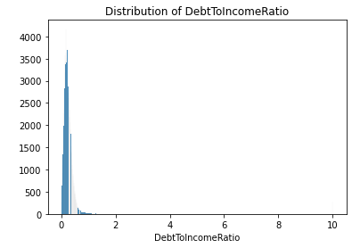

```python
# plotting the DebtToIncomeRatio to get an idea of the variable's distribution.

sb.histplot(df_clean['DebtToIncomeRatio'])
plt.xlabel('DebtToIncomeRatio')
plt.ylabel(' ')
plt.title('Distribution of DebtToIncomeRatio')
plt.show()
```

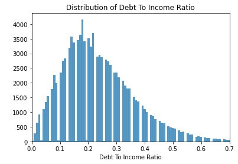

```python
# investigating further on an even smaller bin size

sb.histplot(df_clean['DebtToIncomeRatio'])
plt.xlim([0,0.7])
plt.xlabel('Debt To Income Ratio')
plt.ylabel(' ')
plt.title('Distribution of Debt To Income Ratio')
plt.show()
```

these two plots are showing us the average ratio of debt to income that usully people have. on the debt to income ratio plot most of the data sets of the far left of the axe between zero and two, the distribution of the debt to income ratio takes on a unimodal shap but slightly skeawed, so i had to investigate further on an even smaller bin size. as we can see that the majorty have their debt ratio between 0.1 and 0.3 of their income.

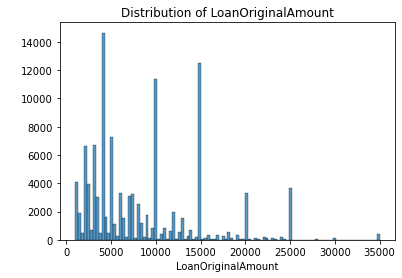

```python
# re-using code to plot LoanOriginalAmount

sb.histplot(df_clean['LoanOriginalAmount'])
plt.xlabel('LoanOriginalAmount')
plt.ylabel(' ')
plt.title('Distribution of LoanOriginalAmount')
plt.show()
```

in the case of the loan original amount there are very large spikes in frequency at the bars these probably represent standerd Loan Amount for use inm loans.

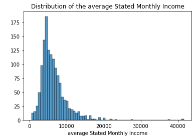

```python
sb.histplot(df_inc['StatedMonthlyIncome'])
plt.xlabel('average Stated Monthly Income')
plt.ylabel(' ')
plt.title('Distribution of the average Stated Monthly Income')
plt.show()
```

In this histgram plot of the average Stated Monthly Income my intent was to see how much is the average of the Stated Monthly Income for people who take loans usually.

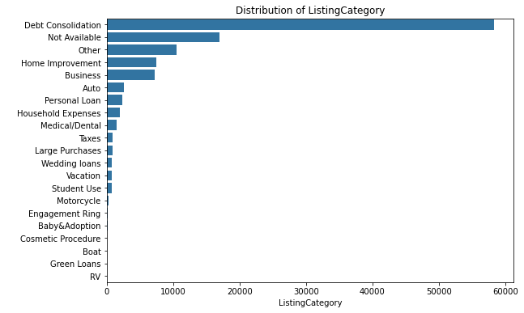

```python
#plot the distribution of ListingCategory

plt.figure(figsize=[9, 6])
base_colour = sb.color_palette()[0]
sb.countplot(data=df_clean,y='ListingCategory',color = base_colour,order = df_clean['ListingCategory'].value_counts().index)
plt.xlabel('ListingCategory')
plt.ylabel(' ')
plt.title('Distribution of ListingCategory')
plt.show()
```

here i wanted to see what are the most reson for people to take loans, and as it obverose that the debt consolidation was the most reason.

I'll now look at the other features in the data to see if any of them hold interesting properties

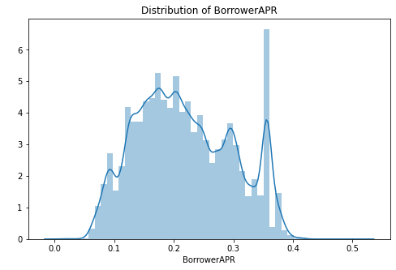

```python
#plotting BorrowerAPR

plt.figure(figsize=[8, 5])
sb.distplot(df_clean['BorrowerAPR'])
plt.xlabel('BorrowerAPR')
plt.ylabel(' ')
plt.title('Distribution of BorrowerAPR')

plt.show()
```

here i wanted to see what is The Borrower's Annual Percentage Rate (APR) for the loan that people usuly have.

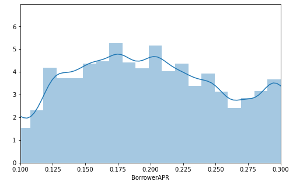

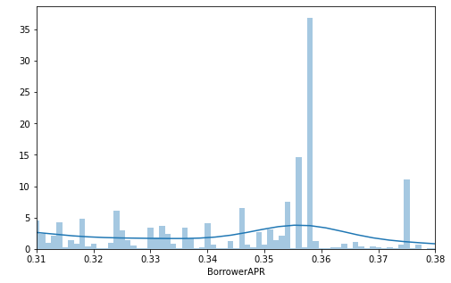

```python
# investigating further on an even smaller bin size

plt.figure(figsize=[8, 5])
sb.distplot(df_clean['BorrowerAPR'])
plt.xlim([0.1,0.3])
plt.xlabel('BorrowerAPR')
plt.ylabel(' ')


bins = np.arange(df_clean['BorrowerAPR'].min(), df_clean['BorrowerAPR'].max(),0.001)
plt.figure(figsize=[8, 5])
sb.distplot(df_clean['BorrowerAPR'],bins=bins)
plt.xlim([0.31,0.38])
plt.xlabel('BorrowerAPR')
plt.ylabel(' ')
plt.show()
```

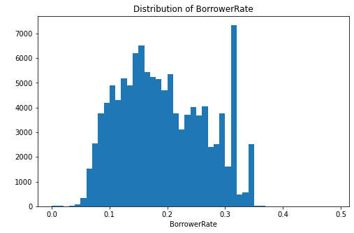

```python
# plotting the BorrowerRate on a standard scale

bins = np.arange(df_clean['BorrowerRate'].min(), df_clean['BorrowerRate'].max(),0.01)

plt.figure(figsize=[8, 5])

plt.hist(data = df_clean, x = 'BorrowerRate', bins = bins)
plt.xlabel('BorrowerRate')
plt.ylabel(' ')
plt.title('Distribution of BorrowerRate')
plt.show()
```

here i wanted to see what is The Borrower's interest rate for the loan that people usully have.

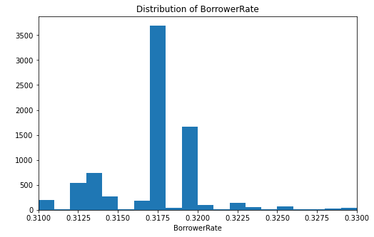

```python
# investigating further on an even smaller bin size

bins = np.arange(df_clean['BorrowerRate'].min(), df_clean['BorrowerRate'].max(),0.001)

plt.figure(figsize=[8, 5])
plt.hist(data = df_clean, x = 'BorrowerRate', bins = bins)
plt.xlim([0.31,0.33])
plt.xlabel('BorrowerRate')
plt.ylabel(' ')
plt.title('Distribution of BorrowerRate')
plt.show()
```

the shape of the BorrowerRate and the borrowerAPR distributions are very similar to one another,It's likely that these variables will be highly correlated with one another.

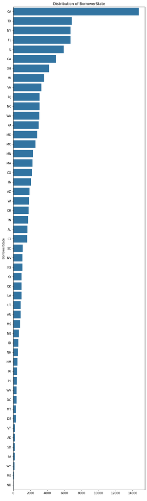

```python
# plotting the BorrowerState to get an idea of the variable's distribution.

fig, ax = plt.subplots( figsize = [8,30])

default_color = sb.color_palette()[0]

sb.countplot(data = df_clean, y = 'BorrowerState', color = default_color,order = df_clean['BorrowerState'].value_counts().index)
plt.xlabel(' ')
plt.ylabel('BorrowerState')
plt.title('Distribution of BorrowerState')
plt.show()
```

i made this plot to observe which states most borrower on this dtatset are living.

Before closing this section, we'll take a look at the last two variables: LoanOriginationYear and LoanOriginationQuarter.

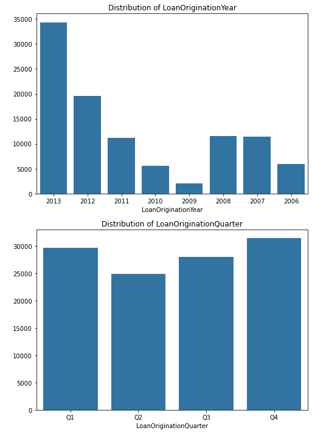

```python
# plot two together to get an idea of each variable's distribution.

plt.figure(figsize = [8, 12])
base_colour = sb.color_palette()[0]

# subplot 1:
plt.subplot(2,1, 1)

year_order = ['2013','2012','2011','2010','2009','2008','2007','2006']
df_clean.LoanOriginationYear=pd.Categorical(df_clean.LoanOriginationYear,categories= year_order,ordered=True)

sb.countplot(data = df_clean, x = 'LoanOriginationYear', color =base_colour)

plt.xlabel('LoanOriginationYear')
plt.ylabel(' ')
plt.title('Distribution of LoanOriginationYear')


# subplot 2:

ax = plt.subplot(2,1, 2)

quarter_order = ['Q1','Q2','Q3','Q4']
df_clean.LoanOriginationQuarter=pd.Categorical(df_clean.LoanOriginationQuarter,categories= quarter_order,ordered=True)

sb.countplot(data = df_clean, x = 'LoanOriginationQuarter', color = base_colour)

plt.xlabel('LoanOriginationQuarter')
plt.ylabel(' ')
plt.title('Distribution of LoanOriginationQuarter')

plt.show()
```

for the last two plots on this section i wanted to see which quarters people usully get loans, but for the plot of the years i think the informations are not giving me the results i hope i will find cause it seems like there are informations has been gathered on some years more than others.

### Discuss the distribution(s) of your variable(s) of interest. Were there any unusual points? Did you need to perform any transformations?

on the debt to income ratio plot most of the data sets of the far left of the axe between zero and two, the distribution is unimodal but slightly skeawed, so i had to investigate further on an even smaller bin size.

### Of the features you investigated, were there any unusual distributions? Did you perform any operations on the data to tidy, adjust, or change the form of the data? If so, why did you do this?

When investigating the ListingCategory column, i had to replace it's numirac variables with their categories for clearer result. also for tidying up i had to split LoanOriginationQuarter column into two separated columns LoanOriginationyear and LoanOriginationQuarter.